# Biostat 203B Homework 4

Due Mar 24 @ 11:59PM

Author

Saanchi Shah and 204591578

Load database libraries and the tidyverse frontend:

```r
suppressPackageStartupMessages(library(tidyverse))
suppressPackageStartupMessages(library(tidymodels))
suppressPackageStartupMessages(library(lubridate))
suppressPackageStartupMessages(library(GGally))
suppressPackageStartupMessages(library(gtsummary))
# install.packages("xgboost")
suppressPackageStartupMessages(library(xgboost))
suppressPackageStartupMessages(library(parsnip))
suppressPackageStartupMessages(library(parsnip))
```

## 0.1 Predicting 30-day mortality

Using the ICU cohort `icu_cohort.rds` you built in Homework 3, develop at least three analytic approaches for predicting the 30-day mortality of patients admitted to ICU using demographic information (gender, age, marital status, ethnicity), first lab measurements during ICU stay, and first vital measurements during ICU stay. For example, you can use (1) logistic regression with elastic net (lasso + ridge) penalty (e.g., glmnet or keras package), (2) random forest, (3) boosting, and (4) support vector machines, or (5) MLP neural network (keras package)

First, I will modify my ICU.rds file because I had an erroneous variable in my original file.

```r
library(tidyverse)

icu_cohort <- readRDS(file = file.path("~/biostat-203b-2023-winter/hw3/mimiciv_shiny", 'icu_cohort.rds'))

icu_cohort_new <- icu_cohort %>%
  mutate(duration_new = difftime(dod, admittime, unit = 'days'),
         thirty_day_mort_new = if_else(is.na(duration_new), 0,
           if_else(duration_new < 30, 1, 0))) %>%
  select(-c(duration, thirty_day_mort))

icu_cohort_new$thirty_day_mort_new <-
  as.factor(icu_cohort_new$thirty_day_mort_new)

icu_cohort_subset <-
  icu_cohort_new %>%
#  filter(!is.na(thirty_day_mort_new)) %>%
  select(c(thirty_day_mort_new,
           gender,
           age,
           Potassium,
           Chloride,
           Sodium,
           ethnicity,
           insurance,
           WBC,
           Hematocrit,
           Sodium,
           Glucose,
           Bicarbonate,
           Creatinine,
           Resp_rate,
           Diastolic_BP,
           Systolic_BP,
           Temperature,
           Heart_rate))
```

# 1 Q1. Partition data into 50% training set and 50% test set. Stratify partitioning according the 30-day mortality status.

```r
library(tidymodels)

# For reproducibility
set.seed(203)

data_split <- initial_split(
  icu_cohort_subset,
  # stratify by thirty_day_mort
  strata = "thirty_day_mort_new",
  prop = 0.50 # 50-50 split as suggested in class
  )
data_split
```

```
<Training/Testing/Total>
<16224/16225/32449>
```

```r
icu_other <- training(data_split)
# check dimensions of training set
dim(icu_other)
```

```
[1] 16224    18
```

```r
# check dimensions of the training data set
icu_test <- training(data_split)
dim(data_split)
```

```
  analysis assessment          n          p
     16224      16225      32449         18
```

# 2 Q2. Train and tune the models using the training set.

### 2.0.1 Pre-processing steps

First, I will preprocess the data for logistic regression, xgboost and random forest

```r
logit_recipe <-
  recipe(
    thirty_day_mort_new ~ .,
    data = icu_other
  ) %>%

  # create traditional dummy variables
  step_dummy(all_nominal_predictors()) %>%
  # zero-variance filter
  # step_impute_mean(Potassium, Sodium, Chloride) %>%
  step_impute_mean(all_numeric_predictors()) %>%
  # would not work without imputations for me
  step_zv(all_numeric_predictors()) %>%
  # center and scale numeric data
  step_normalize(all_numeric_predictors()) %>%
  # estimate the means and standard deviations
  prep(training = icu_other, retain = TRUE)
logit_recipe

# Create model
logit_mod <-
logistic_reg(
  penalty = tune(),
  mixture = tune()
 ) %>%
set_engine("glmnet", standardize = FALSE)
logit_mod
```

```
Logistic Regression Model Specification (classification)

Main Arguments:
  penalty = tune()
  mixture = tune()

Engine-Specific Arguments:
  standardize = FALSE

Computational engine: glmnet
```

```r
# add recipe
logit_wf <- workflow() %>%
  add_recipe(logit_recipe) %>%
  add_model(logit_mod)
logit_wf
```

```
══ Workflow ════════════════════════════════════════════════════════════════════
Preprocessor: Recipe
Model: logistic_reg()

── Preprocessor ────────────────────────────────────────────────────────────────
4 Recipe Steps

• step_dummy()
• step_impute_mean()
• step_zv()
• step_normalize()

── Model ───────────────────────────────────────────────────────────────────────
Logistic Regression Model Specification (classification)

Main Arguments:
  penalty = tune()
  mixture = tune()

Engine-Specific Arguments:
  standardize = FALSE

Computational engine: glmnet
```

```r
# Tune models.

param_grid <- grid_regular(
  penalty(range = c(-6, 3)),
  mixture(),
  levels = c(100, 5)
  )
param_grid
```

```
# A tibble: 500 × 2
      penalty mixture
        <dbl>   <dbl>
 1 0.000001         0
 2 0.00000123       0
 3 0.00000152       0
 4 0.00000187       0
 5 0.00000231       0
 6 0.00000285       0
 7 0.00000351       0
 8 0.00000433       0
 9 0.00000534       0
10 0.00000658       0
# ℹ 490 more rows
```

# 3 Q3)A Compare model classification performance on the test set. Report both the area under ROC curve and accuracy for logistic regression.

###Cross-validation for logistic regression + model fitting**

```r
# install.packages("rsample")
library(rsample)
library(dplyr)
# install.packages("tune")
library(tune)
library(parsnip)


set.seed(203)
folds <- vfold_cv(icu_other, v = 5)

system.time({
  logit_fit <- logit_wf %>%
    tune_grid(
      resamples = folds,
      grid = param_grid,
      metrics = metric_set(roc_auc, accuracy)
    )
})
```

```
   user  system elapsed
 30.558   2.366  32.980
```

```r
logit_fit
```

```
# Tuning results
# 5-fold cross-validation
# A tibble: 5 × 4
  splits               id    .metrics             .notes
  <list>               <chr> <list>               <list>
1 <split [12979/3245]> Fold1 <tibble [1,000 × 6]> <tibble [0 × 3]>
2 <split [12979/3245]> Fold2 <tibble [1,000 × 6]> <tibble [0 × 3]>
3 <split [12979/3245]> Fold3 <tibble [1,000 × 6]> <tibble [0 × 3]>
4 <split [12979/3245]> Fold4 <tibble [1,000 × 6]> <tibble [0 × 3]>
5 <split [12980/3244]> Fold5 <tibble [1,000 × 6]> <tibble [0 × 3]>
```

```
# A tibble: 1,000 × 8
      penalty mixture .metric  .estimator  mean     n std_err
        <dbl>   <dbl> <chr>    <chr>      <dbl> <int>   <dbl>
 1 0.000001         0 accuracy binary     0.906     5 0.00272
 2 0.000001         0 roc_auc  binary     0.827     5 0.00604
 3 0.00000123       0 accuracy binary     0.906     5 0.00272
 4 0.00000123       0 roc_auc  binary     0.827     5 0.00604
 5 0.00000152       0 accuracy binary     0.906     5 0.00272
 6 0.00000152       0 roc_auc  binary     0.827     5 0.00604
 7 0.00000187       0 accuracy binary     0.906     5 0.00272
 8 0.00000187       0 roc_auc  binary     0.827     5 0.00604
 9 0.00000231       0 accuracy binary     0.906     5 0.00272
10 0.00000231       0 roc_auc  binary     0.827     5 0.00604
   .config
   <chr>
 1 Preprocessor1_Model001
 2 Preprocessor1_Model001
 3 Preprocessor1_Model002
 4 Preprocessor1_Model002
 5 Preprocessor1_Model003
 6 Preprocessor1_Model003
 7 Preprocessor1_Model004
 8 Preprocessor1_Model004
 9 Preprocessor1_Model005
10 Preprocessor1_Model005
# ℹ 990 more rows
```

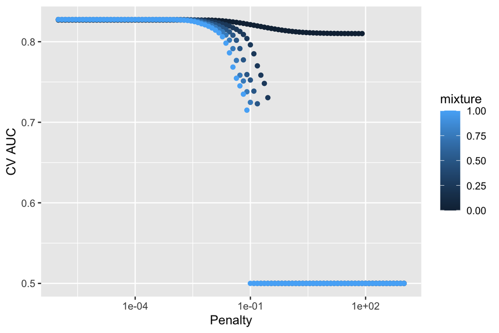

```r
logit_fit %>%
  collect_metrics() %>%
  print(width = Inf) %>%
  filter(.metric == "roc_auc") %>%
  ggplot(mapping = aes(x = penalty, y = mean, color = mixture)) +
  geom_point() +
  labs(x = "Penalty", y = "CV AUC") +
  scale_x_log10()
```

```r
logit_fit %>%
  show_best("roc_auc")
```

```
# A tibble: 5 × 8
     penalty mixture .metric .estimator  mean     n std_err .config
       <dbl>   <dbl> <chr>   <chr>      <dbl> <int>   <dbl> <chr>
1 0.000001       0.5 roc_auc binary     0.828     5 0.00612 Preprocessor1_Model…
2 0.00000123     0.5 roc_auc binary     0.828     5 0.00612 Preprocessor1_Model…
3 0.00000152     0.5 roc_auc binary     0.828     5 0.00612 Preprocessor1_Model…
4 0.00000187     0.5 roc_auc binary     0.828     5 0.00612 Preprocessor1_Model…
5 0.00000231     0.5 roc_auc binary     0.828     5 0.00612 Preprocessor1_Model…
```

```r
best_logit <- logit_fit %>%
  select_best("roc_auc")
best_logit
```

```
# A tibble: 1 × 3
   penalty mixture .config
     <dbl>   <dbl> <chr>
1 0.000001     0.5 Preprocessor1_Model201
```

```r
final_wf <- logit_wf %>%
  finalize_workflow(best_logit)
final_wf
```

```
══ Workflow ════════════════════════════════════════════════════════════════════
Preprocessor: Recipe
Model: logistic_reg()

── Preprocessor ────────────────────────────────────────────────────────────────
4 Recipe Steps

• step_dummy()
• step_impute_mean()
• step_zv()
• step_normalize()

── Model ───────────────────────────────────────────────────────────────────────
Logistic Regression Model Specification (classification)

Main Arguments:
  penalty = 1e-06
  mixture = 0.5

Engine-Specific Arguments:
  standardize = FALSE

Computational engine: glmnet
```

```r
final_fit <-
  final_wf %>%
  last_fit(data_split)
final_fit
```

```
# Resampling results
# Manual resampling
# A tibble: 1 × 6
  splits                id             .metrics .notes   .predictions .workflow
  <list>                <chr>          <list>   <list>   <list>       <list>
1 <split [16224/16225]> train/test sp… <tibble> <tibble> <tibble>     <workflow>
```

```r
final_fit %>%
  collect_metrics()
```

```
# A tibble: 2 × 4
  .metric  .estimator .estimate .config
  <chr>    <chr>          <dbl> <chr>
1 accuracy binary         0.910 Preprocessor1_Model1
2 roc_auc  binary         0.809 Preprocessor1_Model1
```

# 4 Q3)B. Random forest.

### 4.0.1 1. Pre-processing steps (split + recipe)

Since the initial split and preprocessing steps are the same, I will leave them untouched and start with the modeling step.

```r
# model

rf_mod <-
  rand_forest(
    mode = "classification",
    # Number of predictors randomly sampled in each split
    mtry = tune(),
    # Number of trees in ensemble
    trees = tune()
  ) %>%
  set_engine("ranger")
rf_mod
```

```
Random Forest Model Specification (classification)

Main Arguments:
  mtry = tune()
  trees = tune()

Computational engine: ranger
```

```r
# Workflow

rf_wf <- workflow() %>%
  add_recipe(logit_recipe) %>% # including logit_recipe because the recipe is =
  add_model(rf_mod)
rf_wf
```

```
══ Workflow ════════════════════════════════════════════════════════════════════
Preprocessor: Recipe
Model: rand_forest()

── Preprocessor ────────────────────────────────────────────────────────────────
4 Recipe Steps

• step_dummy()
• step_impute_mean()
• step_zv()
• step_normalize()

── Model ───────────────────────────────────────────────────────────────────────
Random Forest Model Specification (classification)

Main Arguments:
  mtry = tune()
  trees = tune()

Computational engine: ranger
```

```r
# tuning grid

param_grid <- grid_regular(
  trees(range = c(100L, 300L)),
  mtry(range = c(1L, 5L)),
  levels = c(3, 5)
  )
param_grid
```

```
# A tibble: 15 × 2
   trees  mtry
   <int> <int>
 1   100     1
 2   200     1
 3   300     1
 4   100     2
 5   200     2
 6   300     2
 7   100     3
 8   200     3
 9   300     3
10   100     4
11   200     4
12   300     4
13   100     5
14   200     5
15   300     5
```

```r
# cross validation

set.seed(203)

folds <- vfold_cv(icu_other, v = 5)
folds
```

```
#  5-fold cross-validation
# A tibble: 5 × 2
  splits               id
  <list>               <chr>
1 <split [12979/3245]> Fold1
2 <split [12979/3245]> Fold2
3 <split [12979/3245]> Fold3
4 <split [12979/3245]> Fold4
5 <split [12980/3244]> Fold5
```

### 4.0.2 2. Best fit model for random forest

```r
# fit cross validation


rf_fit <- rf_wf %>%
  tune_grid(
    resamples = folds,
    grid = param_grid,
    metrics = metric_set(roc_auc, accuracy)
    )
rf_fit
```

```
# Tuning results
# 5-fold cross-validation
# A tibble: 5 × 4
  splits               id    .metrics          .notes
  <list>               <chr> <list>            <list>
1 <split [12979/3245]> Fold1 <tibble [30 × 6]> <tibble [0 × 3]>
2 <split [12979/3245]> Fold2 <tibble [30 × 6]> <tibble [0 × 3]>
3 <split [12979/3245]> Fold3 <tibble [30 × 6]> <tibble [0 × 3]>
4 <split [12979/3245]> Fold4 <tibble [30 × 6]> <tibble [0 × 3]>
5 <split [12980/3244]> Fold5 <tibble [30 × 6]> <tibble [0 × 3]>
```

```
# A tibble: 30 × 8
    mtry trees .metric  .estimator  mean     n std_err .config
   <int> <int> <chr>    <chr>      <dbl> <int>   <dbl> <chr>
 1     1   100 accuracy binary     0.894     5 0.00250 Preprocessor1_Model01
 2     1   100 roc_auc  binary     0.878     5 0.00281 Preprocessor1_Model01
 3     1   200 accuracy binary     0.894     5 0.00235 Preprocessor1_Model02
 4     1   200 roc_auc  binary     0.880     5 0.00248 Preprocessor1_Model02
 5     1   300 accuracy binary     0.894     5 0.00272 Preprocessor1_Model03
 6     1   300 roc_auc  binary     0.880     5 0.00252 Preprocessor1_Model03
 7     2   100 accuracy binary     0.916     5 0.00243 Preprocessor1_Model04
 8     2   100 roc_auc  binary     0.886     5 0.00205 Preprocessor1_Model04
 9     2   200 accuracy binary     0.916     5 0.00212 Preprocessor1_Model05
10     2   200 roc_auc  binary     0.888     5 0.00245 Preprocessor1_Model05
# ℹ 20 more rows
```

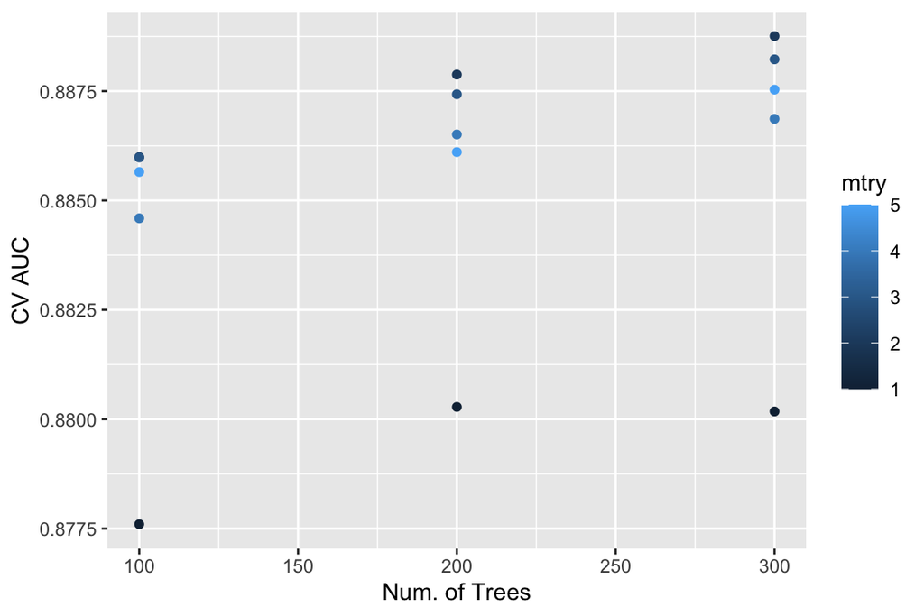

```r
# visualize fit

rf_fit %>%
  collect_metrics() %>%
  print(width = Inf) %>%
  filter(.metric == "roc_auc") %>%
  ggplot(mapping = aes(x = trees, y = mean, color = mtry)) +
  geom_point() +
  # geom_line() +
  labs(x = "Num. of Trees", y = "CV AUC")
```

```r
# show the 5 best models

rf_fit %>%
  show_best("roc_auc")
```

```
# A tibble: 5 × 8
   mtry trees .metric .estimator  mean     n std_err .config
  <int> <int> <chr>   <chr>      <dbl> <int>   <dbl> <chr>
1     2   300 roc_auc binary     0.889     5 0.00260 Preprocessor1_Model06
2     3   300 roc_auc binary     0.888     5 0.00262 Preprocessor1_Model09
3     2   200 roc_auc binary     0.888     5 0.00245 Preprocessor1_Model05
4     5   300 roc_auc binary     0.888     5 0.00297 Preprocessor1_Model15
5     3   200 roc_auc binary     0.887     5 0.00240 Preprocessor1_Model08
```

```r
# Pick the top model

best_rf <- rf_fit %>%
  select_best("roc_auc")
best_rf
```

```
# A tibble: 1 × 3
   mtry trees .config
  <int> <int> <chr>
1     2   300 Preprocessor1_Model06
```

```r
# final workflow

final_wf <- rf_wf %>%
  finalize_workflow(best_rf)
final_wf
```

```
══ Workflow ════════════════════════════════════════════════════════════════════
Preprocessor: Recipe
Model: rand_forest()

── Preprocessor ────────────────────────────────────────────────────────────────
4 Recipe Steps

• step_dummy()
• step_impute_mean()
• step_zv()
• step_normalize()

── Model ───────────────────────────────────────────────────────────────────────
Random Forest Model Specification (classification)

Main Arguments:
  mtry = 2
  trees = 300

Computational engine: ranger
```

```r
# Fit the whole training set, then predict the test cases
final_fit <-
  final_wf %>%
  last_fit(data_split)
final_fit
```

```
# Resampling results
# Manual resampling
# A tibble: 1 × 6
  splits                id             .metrics .notes   .predictions .workflow
  <list>                <chr>          <list>   <list>   <list>       <list>
1 <split [16224/16225]> train/test sp… <tibble> <tibble> <tibble>     <workflow>
```

```r
# Test metrics
final_fit %>%
  collect_metrics()
```

```
# A tibble: 2 × 4
  .metric  .estimator .estimate .config
  <chr>    <chr>          <dbl> <chr>
1 accuracy binary         0.919 Preprocessor1_Model1
2 roc_auc  binary         0.888 Preprocessor1_Model1
```

# 5 Q3)C. Xgboost

### 5.0.1 1. Prepreocessing (split + recipe)

Again, the pre processing steps remain the same so I will start by building the model and go on from there onwards to select the best fit.

```r
# build model

gb_mod <-
  boost_tree(
    mode = "classification",
    trees = 1000,
    tree_depth = tune(),
    learn_rate = tune()
  ) %>%
  set_engine("xgboost")
gb_mod
```

```
Boosted Tree Model Specification (classification)

Main Arguments:
  trees = 1000
  tree_depth = tune()
  learn_rate = tune()

Computational engine: xgboost
```

```r
# workflow

gb_wf <- workflow() %>%
  add_recipe(logit_recipe) %>%
  add_model(gb_mod)
gb_wf
```

```
══ Workflow ════════════════════════════════════════════════════════════════════
Preprocessor: Recipe
Model: boost_tree()

── Preprocessor ────────────────────────────────────────────────────────────────
4 Recipe Steps

• step_dummy()
• step_impute_mean()
• step_zv()
• step_normalize()

── Model ───────────────────────────────────────────────────────────────────────
Boosted Tree Model Specification (classification)

Main Arguments:
  trees = 1000
  tree_depth = tune()
  learn_rate = tune()

Computational engine: xgboost
```

```r
# tuning grid

param_grid <- grid_regular(
  tree_depth(range = c(1L, 3L)),
  learn_rate(range = c(-5, 2), trans = log10_trans()),
  levels = c(3, 10)
  )
param_grid
```

```
# A tibble: 30 × 2
   tree_depth learn_rate
        <int>      <dbl>
 1          1  0.00001
 2          2  0.00001
 3          3  0.00001
 4          1  0.0000599
 5          2  0.0000599
 6          3  0.0000599
 7          1  0.000359
 8          2  0.000359
 9          3  0.000359
10          1  0.00215
# ℹ 20 more rows
```

```r
# Cross validation steps

set.seed(203)

folds <- vfold_cv(icu_other, v = 5)
folds
```

```
#  5-fold cross-validation
# A tibble: 5 × 2
  splits               id
  <list>               <chr>
1 <split [12979/3245]> Fold1
2 <split [12979/3245]> Fold2
3 <split [12979/3245]> Fold3
4 <split [12979/3245]> Fold4
5 <split [12980/3244]> Fold5
```

```r
# fit cross validation

gb_fit <- gb_wf %>%
  tune_grid(
    resamples = folds,
    grid = param_grid,
    metrics = metric_set(roc_auc, accuracy)
    )
gb_fit
```

```
# Tuning results
# 5-fold cross-validation
# A tibble: 5 × 4
  splits               id    .metrics          .notes
  <list>               <chr> <list>            <list>
1 <split [12979/3245]> Fold1 <tibble [60 × 6]> <tibble [0 × 3]>
2 <split [12979/3245]> Fold2 <tibble [60 × 6]> <tibble [0 × 3]>
3 <split [12979/3245]> Fold3 <tibble [60 × 6]> <tibble [0 × 3]>
4 <split [12979/3245]> Fold4 <tibble [60 × 6]> <tibble [0 × 3]>
5 <split [12980/3244]> Fold5 <tibble [60 × 6]> <tibble [0 × 3]>
```

```
# A tibble: 60 × 8
   tree_depth learn_rate .metric  .estimator  mean     n std_err
        <int>      <dbl> <chr>    <chr>      <dbl> <int>   <dbl>
 1          1  0.00001   accuracy binary     0.911     5 0.00260
 2          1  0.00001   roc_auc  binary     0.634     5 0.00506
 3          2  0.00001   accuracy binary     0.911     5 0.00260
 4          2  0.00001   roc_auc  binary     0.718     5 0.00586
 5          3  0.00001   accuracy binary     0.912     5 0.00231
 6          3  0.00001   roc_auc  binary     0.748     5 0.00728
 7          1  0.0000599 accuracy binary     0.911     5 0.00260
 8          1  0.0000599 roc_auc  binary     0.634     5 0.00505
 9          2  0.0000599 accuracy binary     0.911     5 0.00260
10          2  0.0000599 roc_auc  binary     0.725     5 0.00667
   .config
   <chr>
 1 Preprocessor1_Model01
 2 Preprocessor1_Model01
 3 Preprocessor1_Model02
 4 Preprocessor1_Model02
 5 Preprocessor1_Model03
 6 Preprocessor1_Model03
 7 Preprocessor1_Model04
 8 Preprocessor1_Model04
 9 Preprocessor1_Model05
10 Preprocessor1_Model05
# ℹ 50 more rows
```

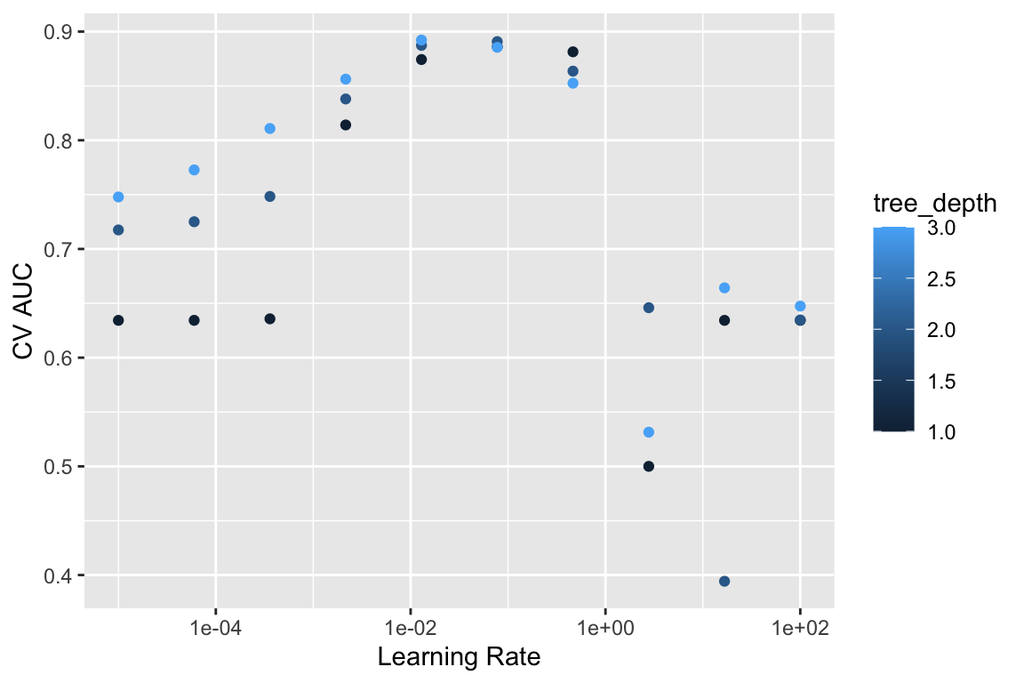

```r
# visualize cross validation

gb_fit %>%
  collect_metrics() %>%
  print(width = Inf) %>%
  filter(.metric == "roc_auc") %>%
  ggplot(mapping = aes(x = learn_rate, y = mean, color = tree_depth)) +
  geom_point() +
  labs(x = "Learning Rate", y = "CV AUC") +
  scale_x_log10()
```

```r
# show top 5 models
gb_fit %>%
  show_best("roc_auc")
```

```
# A tibble: 5 × 8
  tree_depth learn_rate .metric .estimator  mean     n std_err .config
       <int>      <dbl> <chr>   <chr>      <dbl> <int>   <dbl> <chr>
1          3     0.0129 roc_auc binary     0.892     5 0.00204 Preprocessor1_Mo…
2          2     0.0774 roc_auc binary     0.891     5 0.00272 Preprocessor1_Mo…
3          2     0.0129 roc_auc binary     0.887     5 0.00225 Preprocessor1_Mo…
4          1     0.0774 roc_auc binary     0.886     5 0.00184 Preprocessor1_Mo…
5          3     0.0774 roc_auc binary     0.886     5 0.00228 Preprocessor1_Mo…
```

```r
# select the best fit model

best_gb <- gb_fit %>%
  select_best("roc_auc")
best_gb
```

```
# A tibble: 1 × 3
  tree_depth learn_rate .config
       <int>      <dbl> <chr>
1          3     0.0129 Preprocessor1_Model15
```

### 5.0.2 2. Finalize xgboost model

```r
# Final workflow
final_wf <- gb_wf %>%
  finalize_workflow(best_gb)
final_wf
```

```
══ Workflow ════════════════════════════════════════════════════════════════════
Preprocessor: Recipe
Model: boost_tree()

── Preprocessor ────────────────────────────────────────────────────────────────
4 Recipe Steps

• step_dummy()
• step_impute_mean()
• step_zv()
• step_normalize()

── Model ───────────────────────────────────────────────────────────────────────
Boosted Tree Model Specification (classification)

Main Arguments:
  trees = 1000
  tree_depth = 3
  learn_rate = 0.0129154966501488

Computational engine: xgboost
```

```r
# Fit the whole training set, then predict the test cases
final_fit <-
  final_wf %>%
  last_fit(data_split)
final_fit
```

```
# Resampling results
# Manual resampling
# A tibble: 1 × 6
  splits                id             .metrics .notes   .predictions .workflow
  <list>                <chr>          <list>   <list>   <list>       <list>
1 <split [16224/16225]> train/test sp… <tibble> <tibble> <tibble>     <workflow>
```

```r
# Test metrics
final_fit %>%
  collect_metrics()
```

```
# A tibble: 2 × 4
  .metric  .estimator .estimate .config
  <chr>    <chr>          <dbl> <chr>
1 accuracy binary         0.923 Preprocessor1_Model1
2 roc_auc  binary         0.891 Preprocessor1_Model1
```

# 6 Report

**It appears that the accuracy for the model with XgBoost has the maximum accuracy, however, it was not the most efficient in terms of how long it took to run and has very similar predictive capacity as random forest.**

During this homework, we created a variety of different models. To choose between them, we need to consider how well these models do, as measured by some performance statistics. In my homework, I used: the area under the Receiver Operating Characteristic (ROC) curve, and overall classification accuracy. The ROC curve uses the class probability estimates to give us a sense of performance across the entire set of potential probability cutoffs.

Overall, ROC AUC values are pretty close to what we saw when we tuned the random forest model with the validation set AND when we tuned the xgboost model with the validation set, which is good news. (While the same can be applied to logistic regression, it did not perform as well as random forest and xgboost in terms of its accuracy). That means that our estimate of how well our model would perform with new data was not too far off from how well our model actually performed with the unseen test data.